# Introduction to Natural Language Processing - Do Good Data 2016

Dan Acheson

Timshel  
dan@timshel.com

# Dependencies

### Code written in R 3.1.3__ ### The code below should install what you don’t already have__

```r
setwd(getwd())
required_packages <- c('stringr', 'stringi', 'quanteda', 'tm', 'data.table', 'topicmodels', 'e1071', 'wordcloud', 'RColorBrewer', 'proxy', 'ape', 'servr')

new.packages <- required_packages[!(required_packages %in% installed.packages()[,"Package"])]

if(length(new.packages)){
  install.packages(required_packages, repos='http://cran.us.r-project.org')
}
```

# Natural Language Processing

- Techniques, tools and algorithms that will allow computational approaches to language processing
- Historically comes from the combination of a number of fields
  - Computer science
  - Computational linguistics
  - Artificial Intelligence
  - Psychology

## Terminology

- **Natural language:** language produced by humans
- **Text**: the writen form of language
- **String**: computer representation of text (a.k.a., character)
- **Document**: a bunch of text that comes from the same place
  - Can be as large as a whole book, or as small as a single tweet
- **Corpus**: A collection of documents (plural: *corpora*)

## Data Sources for Text

**See additional resources below for more**

1. APIs from the services you love
   - [Twitter API](https://dev.twitter.com/overview/documentation) is particularly is useful
2. Web-scraping
3. PDFs / printed text
   - Need optical character recognition (OCR)
4. Digitized collections of books, newspapers, etc.
   - [Project Gutenberg](https://www.gutenberg.org/)
   - [New York Times](http://www.nytimes.com/ref/membercenter/nytarchive.html)
5. Curated corpora by NLP researchers
6. [Wikipedia!](http://https://dumps.wikimedia.org/)

# Text Wrangling 101

- Very important skills to learn if you’re going to work with text
- Base R has some decent functionality

> `grep gsub substr strsplit tolower/toupper paste/paste0`
- **To start:** UPPER and lower case

```r
myText <- "Do Good Data 2016"
tolower(myText) #lowercase
```

```
## [1] "do good data 2016"
```

```r
toupper(myText) #uppercase
```

```
## [1] "DO GOOD DATA 2016"
```

## String Splitting

- Today we’ll primarily use the [`stringr`](https://cran.r-project.org/package=stringr) package
- Faster and more transparent than base R
- Uses the [`stringi`](https://cran.r-project.org/package=stringi) package underneath

**Comma separated text**

```r
library(stringr)
myText <- "Comma,separated,text"
str_split(myText,",")
```

```
## [[1]]
## [1] "Comma"     "separated" "text"
```

**Email addresses**

```r
myText <- "dan@timshel.com"
str_split(myText,"@")
```

```
## [[1]]
## [1] "dan"         "timshel.com"
```

## String Splitting on a list

**Applying `str_split` on a list**

```r
list_of_emails <- c("fred@flinstones.com", "wilma@flinstones.com","pebbles@flinstones.com")
split_list <- sapply(list_of_emails, function(x) str_split(x,"@"), USE.NAMES =F)
split_list[1:2]
```

```
## [[1]]
## [1] "fred"           "flinstones.com"
##
## [[2]]
## [1] "wilma"          "flinstones.com"
```

```r
#Extract names from list
first_names <- sapply(split_list, function(x) x[1])
last_names <- sapply(split_list, function(x) x[2])
first_names
```

```
## [1] "fred"    "wilma"   "pebbles"
```

## Combining / concatenating text

**Using base R’s `paste` or `paste0`**

```r
split_text = c("My", "text", "in", "a", "vector / list")
split_text
```

```
## [1] "My"            "text"          "in"            "a"
## [5] "vector / list"
```

```r
paste0(split_text, collapse = ",")
```

```
## [1] "My,text,in,a,vector / list"
```

## Trimming

**Remove trailing or leading whitespace (e.g., a newline) with `str_trim`**

```r
myText = "  Space at beginning removed"
str_trim(myText, side = "left")
```

```
## [1] "Space at beginning removed"
```

```r
myText = "Text with carriage return and newlines removed\r\n"
str_trim(myText, side = "right")
```

```
## [1] "Text with carriage return and newlines removed"
```

# Regular Expressions

**A brief but important aside**

- Regular Expressions (i.e., regexes) are simple yet powerful language for finding patterns in text
- If you don’t know ’em, go out and learn ’em.
- You’ll find tons of applications and seriously increase your ability to search, munge and manipulate text.
- For more info, check the following: [regex in stringi](http://finzi.psych.upenn.edu/library/stringi/html/stringi-search-regex.html)

## Regular Expression Syntax:

[output not shown]

# Wrangling Continued

## Substituting / Replacing

**Getting rid of numbers**

```r
myText = "Text with 9879numbers 54 I do43n't wan234t"
str_replace_all(myText,"[0-9]+","")
```

```
## [1] "Text with numbers  I don't want"
```

```r
#Alternate version
str_replace_all(myText,"[:digit:]","")
```

```
## [1] "Text with numbers  I don't want"
```

## Extracting Text

**Extract email addresses!**

```r
myText = "Address 1: dan@timshel.com, Address 2: barney_rubble@flinstones.com"
str_extract_all(myText, "[a-zA-Z0-9_]+@.*.[a-zA-Z]+", simplify = T)
```

```
##      [,1]
## [1,] "dan@timshel.com, Address 2: barney_rubble@flinstones.com"
```

**There are two mistakes above. Can you spot them?**

### Extracting Email - Correct

**Remember `.*` is *greedy*, so be careful!** **Here using `.*?` and escaping the . with `\\.`**

```r
#NOTE: In R, escape is \\
str_extract_all(myText, "[a-zA-Z0-9_]+@.*?\\.[a-zA-Z]+", simplify = T)
```

```
##      [,1]              [,2]
## [1,] "dan@timshel.com" "barney_rubble@flinstones.com"
```

### Extracting HTML content

**Using the `str_match` function**

```r
html <- paste(readLines("./pres_data/example.html"), collapse="\n")
regex = "<li>(.*?)</li>"
str_match_all(html, regex)
```

```
## [[1]]
##      [,1]
## [1,] "<li>Lorem ipsum dolor sit amet, consectetuer adipiscing elit.</li>"
## [2,] "<li>Aliquam tincidunt mauris eu risus.</li>"
## [3,] "<li>Vestibulum auctor dapibus neque.</li>"
##      [,2]
## [1,] "Lorem ipsum dolor sit amet, consectetuer adipiscing elit."
## [2,] "Aliquam tincidunt mauris eu risus."
## [3,] "Vestibulum auctor dapibus neque."
```

## Why learn all of this manual text-processing?

- Forms of the basis of text processing we’ll see later
- Gives you the tools to customize!
- Can quickly get to word frequencies, which can be VERY informative

# Word Frequencies

## Example

- Let’s look at frequencies from ‘Alice in Wonderland’
- Data comes from [Project Gutenberg](https://www.gutenberg.org/)

**Load and Pre-Process**

```r
alice <- "./pres_data/alice.txt"
#read into a character vector
alice <- paste(readLines(alice), collapse = "\n")
#Simple pre-processing
pre_process <- function(txt) {
  txt <- tolower(txt)
  txt <- str_replace_all(txt, "\n", " ") #newline with space
  txt <- str_replace_all(txt,"[ ]{2,}", " ") #extra spaces
  txt <- str_replace_all(txt, "[^a-zA-Z ]","") #only keep letters
  return(txt)
}
#Pre-process
alice <- pre_process(alice)

#Get Frequencies
words <- str_split(alice," ")
freqs <- table(words)
freqs <- freqs[order(freqs,decreasing = T)]
freqs[1:8]
```

```
## words
##  the  and   to    a  she   it   of said
## 1631  844  721  627  537  526  508  462
```

**What do you notice?**

## Plotting word frequencies with wordclouds

**Using the [`wordcloud`](https://cran.r-project.org/web/packages/wordcloud/) package** **We *COULD* use our frequency table…**

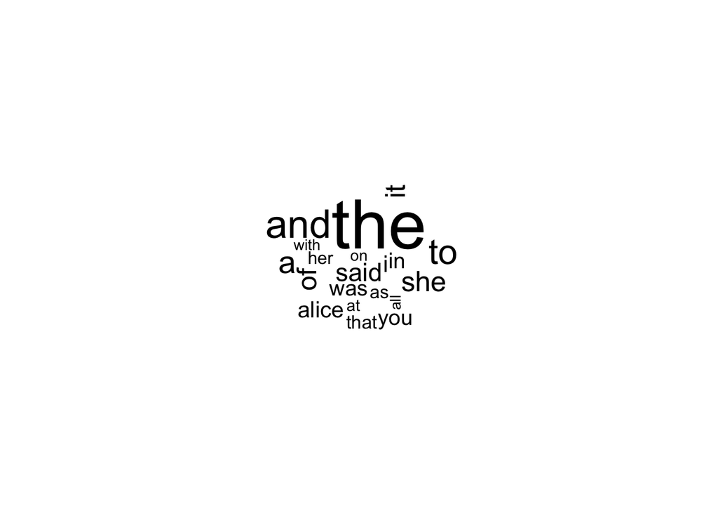

```r
library(wordcloud)
wordcloud(words = names(freqs), freq = as.numeric(freqs), max.words = 20, scale = c(4,0.5))
```

**Or, we can just take advantage of the package :)**

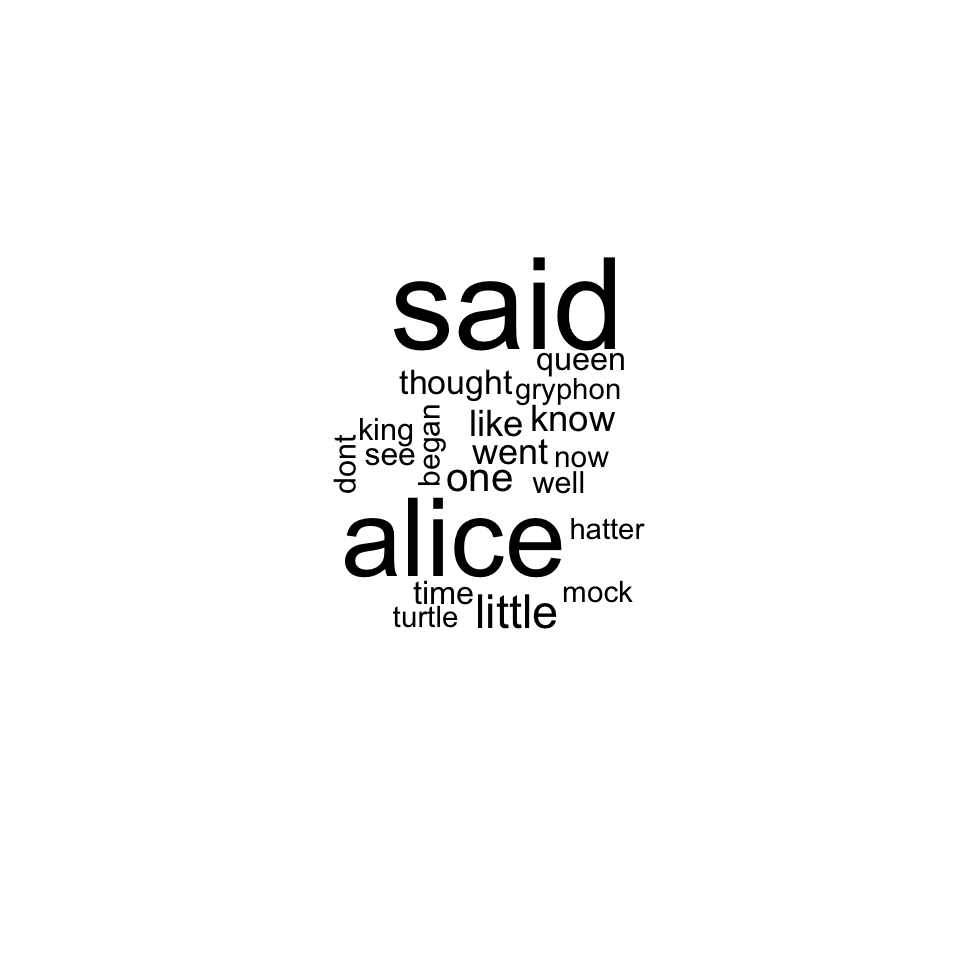

```r
wc2 = wordcloud(alice, max.words = 20, scale = c(4,0.5))
```

## Wordclouds with color!

**Use two visual dimensions to emphasize frequency differences**

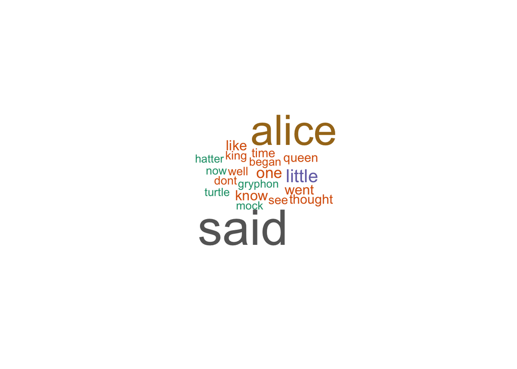

```r
library(RColorBrewer)
pal <- brewer.pal(8,"Dark2")

wordcloud(alice, max.words = 20, scale = c(4,0.5), color = pal)
```

## Why all this focus on word frequencies?

1. They’re informative!
2. They are the basis of:

[**THE VECTOR-SPACE MODEL**](https://en.wikipedia.org/wiki/Vector_space_model)

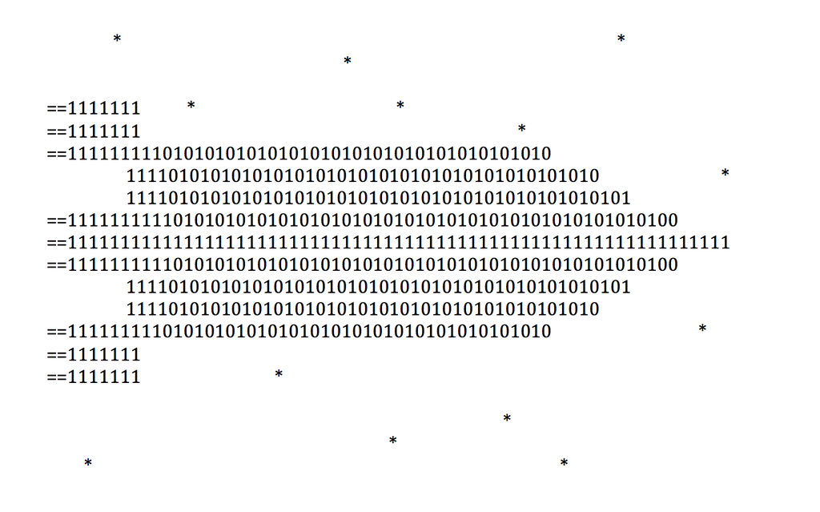

# The Vector Space / N-Gram Model

**Representing documents as vectors**

[output not shown]

**The document feature or document term matrix**

```
## Document-feature matrix of: 2 documents, 9 features.
## 2 x 9 sparse Matrix of class "dfmSparse"
##        features
## docs    ate cow cows grass jumped moon. over the The
##   text1   0   1    0     0      1     1    1   1   1
##   text2   1   0    1     1      0     0    0   0   1
```

## Pre-processing text for vector space model

**Pre-processing depends on what you’re doing. But generally:** 1. Remove punctuation 2. Tokenization(https://en.wikipedia.org/wiki/Tokenization_(lexical_analysis) 3. Remove stop-words (e.g., “a”, “the”, etc.) 4. Lowercase 5. Remove low-frequency words 6. Stemming

### Tokenization

**How you break up your text into meaningful units for analysis**  
- Could be individual words - Unigram / bag of words representation

- Could be pairs or triples of words
- bigram / trigram
- Could be sentences, paragraphs, etc.

### Word stemming

- Treat similar forms of a word: *run*, *runs*, *running*, *runner*?
- As the same word: *run*

**Reasons for doing it:**

- Reduce vocabulary size
- Increase similarity across texts

**Reasons to not do it:**

- Lose information

#### Word stemming - main types

1. Remove suffixes from words *run*, *runs*, *running*, *runner* -> run
- Common algorithms:
  - Porter, Snowball, Lancaster, regexp
2. Lemmatization
- Use syntactic analysis to remove inflectional (i.e., sytnactic) endings *am*, *is*, *are* -> be

# Vectorizing documents

- Thankfully, all of this pre-processing is built into packages / libraries that handle text!
- Today we’ll use the [`quanteda`](https://cran.r-project.org/package=quanteda) package

```r
library(quanteda)
txt  = c("The cow jumped over the moon.", "The cows ate grass")
#Convert text list to a corpus
txt_corpus = corpus(txt)
doc_mat2 = dfm(txt_corpus, clean = T, stem = T, ignoredFeatures = stopwords("english"), verbose = F)
doc_mat2
```

```
## Document-feature matrix of: 2 documents, 5 features.
## 2 x 5 sparse Matrix of class "dfmSparse"
##        features
## docs    ate cow grass jump moon
##   text1   0   1     0    1    1
##   text2   1   1     1    0    0
```

## Effects of pre-processing

**No Pre-Processing**

```
## Document-feature matrix of: 2 documents, 9 features.
## 2 x 9 sparse Matrix of class "dfmSparse"
##        features
## docs    ate cow cows grass jumped moon. over the The
##   text1   0   1    0     0      1     1    1   1   1
##   text2   1   0    1     1      0     0    0   0   1
```

**With Pre-Processing**

```
## Document-feature matrix of: 2 documents, 5 features.
## 2 x 5 sparse Matrix of class "dfmSparse"
##        features
## docs    ate cow grass jump moon
##   text1   0   1     0    1    1
##   text2   1   1     1    0    0
```

## From unigrams to n-grams

- So far what we’ve done is a unigram, or bag-of-words model
- Can also incorporate bigrams

```
## Document-feature matrix of: 2 documents, 8 features.
## 2 x 8 sparse Matrix of class "dfmSparse"
##        features
## docs    ate ate_grass cow cow_jump grass jump jumped_ov moon
##   text1   0         0   1        1     0    1         1    1
##   text2   1         1   1        0     1    0         0    0
```

- If you want to move to trigrams, check out the [`tm`](https://cran.r-project.org/package=tm) package
- **Food for thought:** *What happens to our matrix as we add bigrams, trigrams, etc?*

# Normalizing a document-term matrix

## What happens if documents are different lengths?

**A corpus of Alice in Wonderland and our single sentence used before**

```r
library(quanteda)
txt  = c("The cow jumped over the moon.", alice)
txt_corpus = corpus(txt)
doc_mat3 = dfm(txt_corpus, clean = T, stem = F, ignoredFeatures = stopwords("english"), verbose = F)
sort(doc_mat3)[,1:10]
```

```
## Document-feature matrix of: 2 documents, 10 features.
## 2 x 10 sparse Matrix of class "dfmSparse"
##        features
## docs    said alice little one know like went thought queen time
##   text1    0     0      0   0    0    0    0       0     0    0
##   text2  462   385    128 101   85   85   83      74    68   68
```

## Normalization techniques

- Normalize by frequency within each document (i.e., row of our document-term matrix)
- There are many ways you could do this

### Relative frequency

```r
relFreq = weight(doc_mat3, type = "relFreq")
sort(relFreq)[,1:5]
```

```
## Document-feature matrix of: 2 documents, 5 features.
## 2 x 5 sparse Matrix of class "dfmSparse"
##        features
## docs          jumped         moon       cow       said      alice
##   text1 0.3333333333 3.333333e-01 0.3333333 0          0
##   text2 0.0004747962 7.913271e-05 0         0.03655931 0.03046609
```

### Maximum frequency

```r
relFreq = weight(doc_mat3, type = "relMaxFreq")
sort(relFreq)[,1:5]
```

```
## Document-feature matrix of: 2 documents, 5 features.
## 2 x 5 sparse Matrix of class "dfmSparse"
##        features
## docs        jumped        moon cow said     alice
##   text1 1.00000000 1.000000000   1    0 0
##   text2 0.01298701 0.002164502   0    1 0.8333333
```

- Other common options:
  - **natural log**
  - **length normalization**

## Term Frequency Inverse Document Frequency (TFIDF)

### Some insight into what’s going on

**The effect of TFIDF is to emphasize words that frequent within a document, and infrequent across documents**

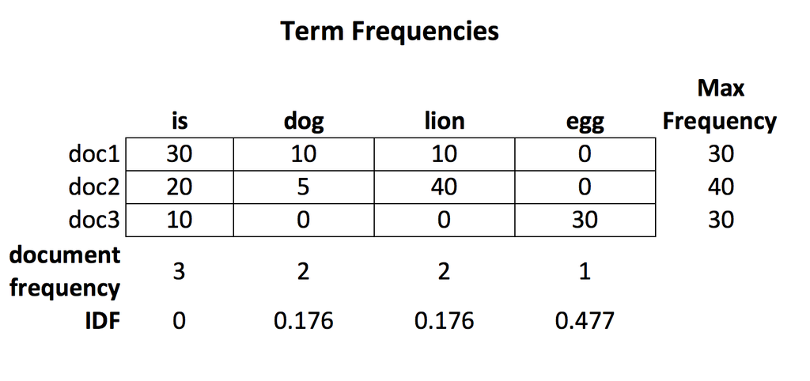

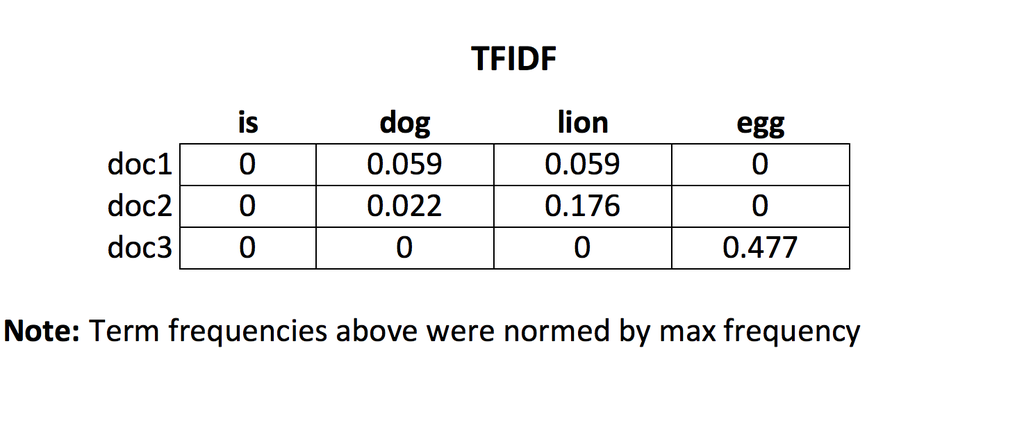

```r
tfidf_norm = weight(doc_mat2, type = "tfidf")
sort(tfidf_norm)[,1:5]
```

```
##        features
## docs          ate     grass      jump      moon cow
##   text1 0.0000000 0.0000000 0.2310491 0.2310491   0
##   text2 0.2310491 0.2310491 0.0000000 0.0000000   0
## attr(,"weighting")
## [1] "tfidf"
## attr(,"class")
## [1] "dfm"    "matrix"
```

# Machine Learning with Text

**After all the vectorizing, we end up with a matrix of features to use for many different tasks:**

- **Unsupervised learning:**
  - clustering
  - document similarity
  - semantic analysis
- **Supervised learning:**
  - sentiment analysis
  - document classification / tagging
- **Information retrieval**

## Clustering / Document Similarity

**Answers the question:** Which of our documents group together based the language they contain?

Basic Procedure:

1. Clean and vectorize text
2. Create a distance / similarity matrix (not always)
3. Cluster

### Clustering Example: Tweets about sustainable development

**The data:** Downloaded from the Twitter search API looking for *“sustainable development”* and *“SDG”*

```r
tweets = read.csv("./pres_data/twitter_dat.csv", stringsAsFactors = F)
print(tweets$text[1])
```

```
## [1] "RT @CUBAONU: #CPD49 #Cuba proves that sustainable development can be reached  w/ political will https://t.co/fatAie4Gyr #UNPopulation"
```

```r
dim(tweets)
```

```
## [1] 20062     2
```

```r
#Let's remove retweets
RTs <- sapply(tweets$text, function(x) str_detect(x, "RT "))
tweets <- tweets[!(RTs),]
dim(tweets)
```

```
## [1] 8771    2
```

The `clean tweets` function below is a modification from this blogpost

```r
clean_tweets <- function(txt) {
  #Args:
  #  txt: character vector of text from twitter

  #Returns:
  # txt:  cleaned character vector of text

  # remove retweet entities
  txt = str_replace_all(txt, "(RT|via)((?:\\b\\W*@\\w+)+)", "")
  # remove at people
  txt = str_replace_all(txt,"@\\w+", "")
  # remove html links
  txt = str_replace_all(txt,"http\\S+", " ")
  # remove punctuation
  txt = str_replace_all(txt,"[[:punct:]]", " ")
  # remove numbers
  txt = str_replace_all(txt, "[[:digit:]]", " ")
  # remove unnecessary spaces
  txt = str_replace_all(txt,"[ \t]{2,}", " ")
  txt = str_trim(txt,"both")
  # remove single character words remaining
  txt = str_replace_all(txt, " [a-zA-Z] "," ")
  txt = tolower(txt)
  return(txt)
}
```

#### Clean the tweets

```r
tweets$text_clean = sapply(tweets$text, function(x) clean_tweets(x))
#Uncleaned
print(tweets$text[1:2])
```

```
## [1] "#CPD49 #Cuba proves that sustainable development can be reached  w/ political will https://t.co/fatAie4Gyr #UNPopulation"
## [2] "What are the #globalgoals? The full list is here.  https://t.co/mXdcm574IN"
```

```r
#Cleaned
print(tweets$text_clean[1:2])
```

```
## [1] "cpd cuba proves that sustainable development can be reached political will unpopulation"
## [2] "what are the globalgoals the full list is here"
```

#### Vectorizing for clustering

- Choice of how you vectorize will depend on the simililarity metric you use
  - frequency or tfidf coded
  - binary coding
- Some choices during pre-processing:
  - stem?
  - removed words
  - frequency cutoffs

```r
tweet_corpus = corpus(tweets$text_clean)
tweet_dfm = dfm(tweet_corpus, clean = T, verbose = F,
                ignoredFeatures = c(stopwords("english"),"sustainable","development","goals"))
dim(tweet_dfm)
```

```
## [1]  8771 10064
```

```r
#remove terms with low frequency across documents
tweet_dfm = trim(tweet_dfm, minDoc = 40, verbose = T)
```

```
## Features occurring in fewer than 40 documents: 9805
```

```r
tweet_dfm = weight(tweet_dfm, method = "tfidf")
```

#### Calculate distance / similarity

- Many different ways of calculating distance / similarity:
  - Euclidean
  - Jaccard
  - Cosine
- Distance calculations can take a while depending on the size of the matrix.
- Solutions:
  - Reduce the size of the matrix
  - Consider trying to parallelize
- The proxy package has a number of distance / similarity measures available
- Here we do Euclidean distance after scaling each column
  - This is roughly equivalent to cosine similarity

```r
library(proxy)
#Only perform on a subset to save some time
tweet_dfm_sub = tweet_dfm[1:3000,]
sim_mat = dist(scale(tweet_dfm_sub))
```

### Hierarchical Clustering

- Challenges:
- where to make the cuts / how many clusters?
- how to [visualize](http://rpubs.com/gaston/dendrograms)?

**Perform hierarchical clustering**

```r
hier_clust = hclust(sim_mat, method="ward.D")
```

#### Visualizing Hierarchical Clusters: Dendrograms

Part of the reason for plotting this is to look for how things are grouping together - This should give you insight into how many clusters you might try to extract or where you might make cuts **From base R** `hclust`

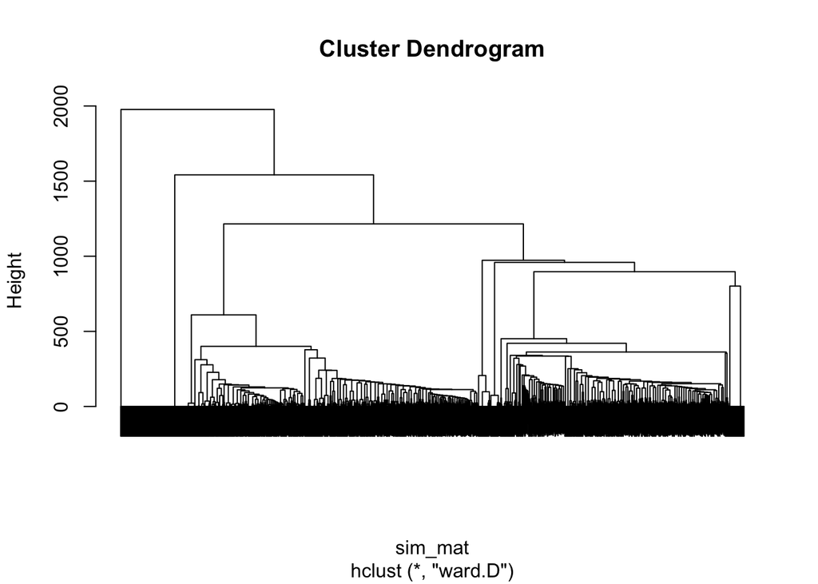

```r
plot(hier_clust, labels = F)
```

**Fan plot** from ape package

[figure not shown]

```r
library(ape)
plot(as.phylo(hier_clust), type = "fan")
```

#### Visualizing Clusters of Text with Wordclouds

**Steps:**

1. Assign documents to a group by cutting the tree
2. Look at wordclouds for each group

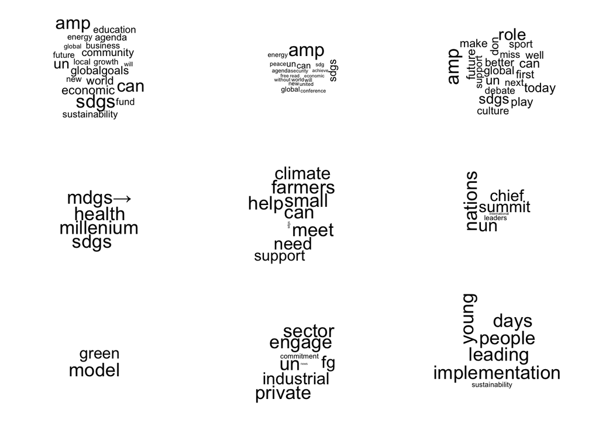

```r
#Cut into 20 groups
groups = cutree(hier_clust, k = 20)

#Plot wordclouds
par(mfrow = c(3,3))
for(group in seq(1,17,2)){
  group_dat = tweet_dfm_sub[which(groups==group),]
  plot(group_dat, max.words = 20, scale = c(2,0.2))
}
```

### KMeans Clustering

- One advantage of using KMeans: No similarity matrix needed!
- Still need to think about:
  - preprocessing
  - choice of K
  - visualizing

```r
k = 20
kmeans_clust = kmeans(tweet_dfm[1:3000,], centers = k)
groups = kmeans_clust$cluster
```

#### Plotting KMeans

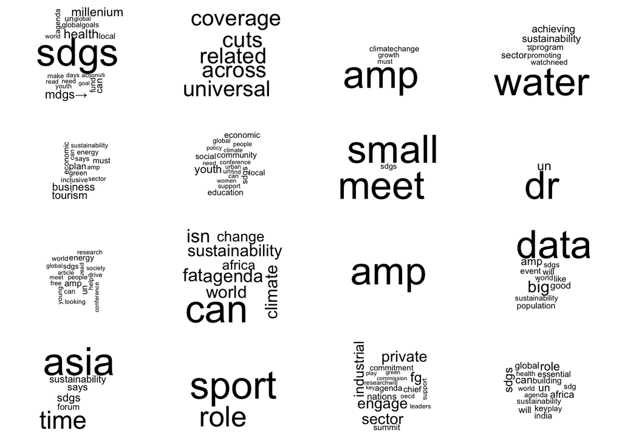

## Semantic Analysis through topic modeling

**Answers the question:** What is the underlying meaning captured in different documents?

- [Topic modeling](https://en.wikipedia.org/wiki/Topic_model) is a statistical approach to natural language processing that find patterns in documents where words within the document can be assigned to abstract ‘topics’
- A document about sports is likely to have a different distribution of words than a document about cooking
- Check out material from [David Blei](https://www.cs.princeton.edu/~blei/topicmodeling.html) for good intros

### Approaches to topic modeling

**[Latent Semantic Indexing (LSI) / Latent Semantic Analysis (LSA)](https://en.wikipedia.org/wiki/Latent_semantic_indexing)** - uses singular value decomposition (SVD) over a document-term matrix - equivalent to multivariate principle components analysis (PCA)

**[Latent Dirichlet Allocation (LDA)](https://en.wikipedia.org/wiki/Latent_Dirichlet_allocation)** - a generative (i.e, probabilistic) framework for estimating topics - assumes each document is a mixture of topics defined by the words in the document - most commonly used today

### Latent Dirichlet Allocation (LDA)

#### Algorithm

- Initialization
  - Choose the number of topics
  - Randomly assign topics to words within a document according to a dirichlet distribution
  - Gives you distributio of words over topics and distribution of topics over documents
- Learning - iteratively repeat the following: For each document calculate:
  - Probabality of each topic given the words in the document
  - For each word, the probability of the different topics based on the topic assignment of that word in the other documents

#### Text pre-processing for LDA

- LDA works off of raw term frequencies. So, tfidf is out here.
- Preprocessing:
  - lowercase, punctuation and stop-word removal
  - tokenization
  - stemming
  - Removing low frequency words
    - document occurence
    - using tfidf cutoff

### LDA over DoGoodData session descriptions

- Let’s have some fun with DoGoodData’s data!
- Data is a webscrape of the session description
- This is a toy example, and is **not** the right data for topic modeling
  - there aren’t enough documents
  - text is sometimes not very long
- All that being said…today we’ll use the [`topicmodels`](https://cran.r-project.org/web/packages/topicmodels/index.html) library

**Create a document-term matrix as before**

```r
library(topicmodels)
dgd_txt = textfile("./pres_data/DoGoodData_sessions/*.txt", cache = F)
dgd_corpus1 = corpus(dgd_txt)
dgd_dfm1 = dfm(dgd_corpus1, clean = T, verbose = F,
              ignoredFeatures = stopwords("english"))
paste0("Matrix dimensions: ", paste(dim(dgd_dfm1), collapse = " X "))
```

```
## [1] "Matrix dimensions: 80 X 2645"
```

**Run the topic model with 10 topics**

```r
dgd_LDA10 <- LDA(convert(dgd_dfm1, to = "topicmodels"), k = 10)
```

#### LDA1 - Results

```r
get_terms(dgd_LDA10,5)
```

```
##      Topic 1  Topic 2       Topic 3    Topic 4   Topic 5     Topic 6
## [1,] "data"   "data"        "will"     "data"    "data"      "data"
## [2,] "solar"  "will"        "data"     "will"    "will"      "will"
## [3,] "will"   "health"      "learning" "open"    "nonprofit" "design"
## [4,] "can"    "information" "machine"  "stories" "can"       "can"
## [5,] "impact" "use"         "discuss"  "session" "tools"     "survey"
##      Topic 7     Topic 8    Topic 9  Topic 10
## [1,] "data"      "data"     "data"   "data"
## [2,] "can"       "will"     "will"   "will"
## [3,] "will"      "analysis" "can"    "crisis"
## [4,] "system"    "social"   "water"  "feedback"
## [5,] "analytics" "well"     "better" "text"
```

What do you think?

#### “Improving” our LDA

Lots of repeated terms across topics

```r
topfeatures(dgd_dfm1)
```

```
##          data          will           can           use       session
##           341           184            84            59            50
## organizations         learn         using        social   information
##            47            43            41            37            36
```

Definitely too many topics given our corpus size

```r
top_remove =  names(topfeatures(dgd_dfm1)[1:8])
dgd_dfm = dfm(dgd_corpus, clean = T, verbose = F,
              ignoredFeatures = c(top_remove,stopwords("english")))
#run with 4 topics only
dgd_LDA4<- LDA(convert(dgd_dfm, to = "topicmodels"), k = 4)
get_terms(dgd_LDA4,5)
```

```
##      Topic 1   Topic 2     Topic 3        Topic 4
## [1,] "impact"  "solar"     "open"         "process"
## [2,] "social"  "analysis"  "organization" "analysis"
## [3,] "us"      "change"    "information"  "analytics"
## [4,] "program" "community" "learning"     "feedback"
## [5,] "system"  "nonprofit" "machine"      "nonprofit"
```

- **NOTE:** removing terms as below is not typical for topic modeling
- It’s done here to illustrate the differerences between topics

#### Visualizing Topic Models - wordclouds

- Wordclouds here came from topic models run on nonprofit mission statements located in their 990 tax forms
- Words are top X words for a topic, Size correspond to the weight.

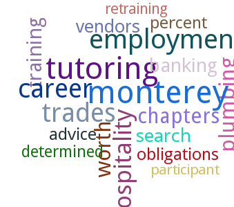

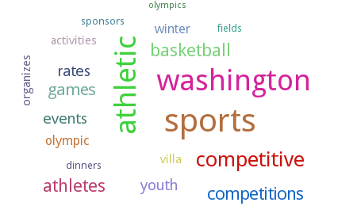

#### Visualizing Topic Models - networks

- Nodes are words, edges are associations to the same topic

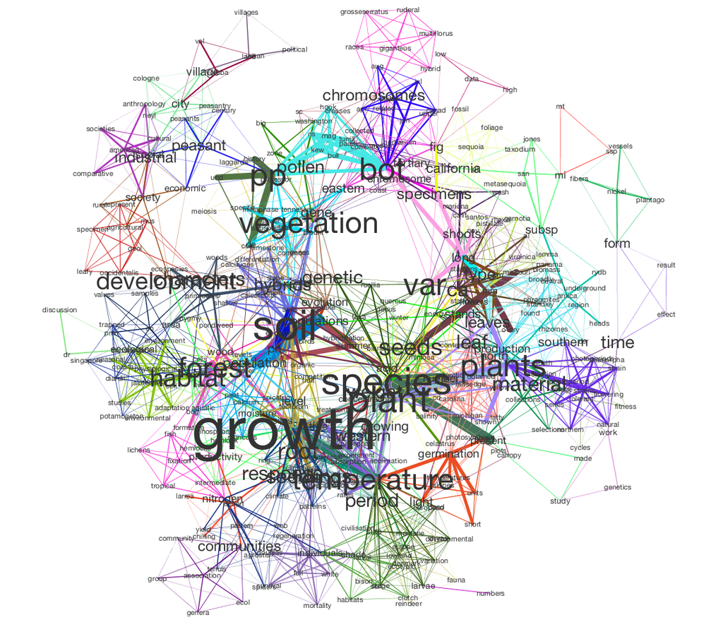

image comes from [tetne tutorial](http://diging.github.io/tethne/api/tutorial.mallet.html)

#### Visualizing Topic Models with LDAvis

- LDAvis: a fantastic tool for both R and Python
- Trick is to get your topic model data in the right format
- Here, I modified some code from [Christopher Gandrud](http://christophergandrud.blogspot.com/2015/05/a-link-between-topicmodels-lda-and.html) (hidden below)

```r
#' Convert the output of a topicmodels Latent Dirichlet Allocation to JSON
#' for use with LDAvis
#'
#' @param fitted Output from a topicmodels \code{LDA} model.
#' @param corpus Corpus object used to create the document term
#' matrix for the \code{LDA} model. This should have been create with
#' the tm package's \code{Corpus} function.
#' @param doc_term The document term matrix used in the \code{LDA}
#' model. This should have been created with the quanteda's
#' \code{dtm} function.
#'
#' @seealso \link{LDAvis}.
#' @export

topicmodels_json_ldavis <- function(fitted, corpus, doc_term){
    # Required packages
    library(topicmodels)
    library(quanteda)
    library(LDAvis)

    # Find required quantities

    phi <- as.matrix(posterior(fitted)$terms) #a matrix with the topic-term distributions
    theta <- as.matrix(posterior(fitted)$topics) #a matrix with the document-topic distributions
    #vocabulary used to fit model
    vocab = doc_term@Dimnames$features
    #summary of corpus, used to get token count for each document
    corpus_summary = summary(corpus, verbose = F)
    doc_length = corpus_summary$Tokens

    term_frequency = doc_term@p[2:length(doc_term@p)] #first element is 0

    # Convert to json
    json_lda <- LDAvis::createJSON(phi = phi, theta = theta,
                            vocab = vocab,
                            doc.length = doc_length,
                            term.frequency = term_frequency)#freq_matrix$Freq)

    return(json_lda)
}
```

**Process data and serve it up**

```r
#Visualizing the original topic model
lda_vis_dat <- topicmodels_json_ldavis(fitted = dgd_LDA10, corpus = dgd_corpus1, doc_term = dgd_dfm1)
```

```
## Corpus consisting of 80 documents.
```

```r
# This should open a viewer in your RStudio session or a browser window
serVis(lda_vis_dat)
```

### How do you know if your model is right?

This is hard to answer directly for unsupervised learning tasks - **Do the topics make sense?** - Use your own judgment for this. There is no ‘correct’ answer.

- **[Perplexity](http://qpleple.com/perplexity-to-evaluate-topic-models/) on a hold-out set of documents**
  - How “confused” is the model with it’s predictions for the words in the documents
- **Can the results be used for another task?** E.g., supervised learning
  - In the end of topic modeling or clustering you’ve reduced your high-dimensional matrix into a much lower-dimensional representation
    - Could be a cluster assignment for a given document
    - Could be the topic loadings
  - Does this new way of representing the data help in a supervised learning task? If so, then you’re on to something.

## Supervised learning with text

Using our vectorized text as features to learn about a known outcome variable **Today:** - Sentiment Analysis - Document Classification

Commonly-used algorithms: - Naive Bayes - Multinomial logistic regression (a.k.a. maximum entropy; maxent) - Support Vector Machines

Things that don’t work so well: - Ensemble techniques like: - Random Forests - Gradient Boosting Machines

### Sentiment Analysis

**Answers the question:** What is the emotional valence of a particular piece of text? Old school: - create a dictionary of positive / negative terms - count frequency for each text source - majority count wins or difference/ratio of positive to negative

Through the lens of machine learning: - Positive / negative valence can be seen as an outcome variable - This simply amounts to a supervised learning problem: - **Categorization:** Sentiment classified as positive, negative or neutral - **Regression:** Sentiment varies continuously from negative to positive - Categorization is more frequent

#### Classifying sentiments of Tweets

- Data comes from the [twitter sentiment corpus](http://thinknook.com/twitter-sentiment-analysis-training-corpus-dataset-2012-09-22/)
- Each tweet is categorized as negative (“0”) or positive (“1”)

```r
library(data.table)
twit_dat = fread("./pres_data/Twitter_Sentiment_Data.csv")
dim(twit_dat)
```

```
## [1] 50000     4
```

```r
names(twit_dat)
```

```
## [1] "ItemID"           "Sentiment"       "SentimentSource" "SentimentText"
```

```r
twit_dat$SentimentText[1:5]
```

```
## [1] "#niley wooooooo new untouchable #niley its really awesome #niley it doesn't have any #niley in it though"
## [2] "g'bye FL crew! until dragon*con!"
## [3] "@apostropheme i'm a real BOY goddamit!!!!!!!!!!!!!! guh. apostro. i feel sad. the library lady thinks i'm stupid. SHE'S STUPID.  j"
## [4] "&quot;PembsDave He's gone now"
## [5] "@Abigailjune92 Weeeeeelllllll helllllllo abbiie! No one ever tells me they have twitter and I've had it for ages. Hope you're not too ill"
```

#### Data preprocessing for twitter sentiment

```r
twit_dat$text_clean <- clean_tweets(twit_dat$SentimentText)

tweet_corpus = corpus(twit_dat$text_clean)
tweet_dfm = dfm(tweet_corpus, clean = T, verbose = F,
                ignoredFeatures = c(stopwords("english")))
dim(tweet_dfm)
```

```
## [1] 50000 36206
```

```r
#remove terms with low frequency across documents
tweet_dfm = trim(tweet_dfm, minDoc = 200, verbose = T)
```

```
## Features occurring in fewer than 200 documents: 35921
```

```r
tweet_dfm = weight(tweet_dfm, method = "tfidf")
```

#### Train a Naive Bayes classifier

Using the `e1071` library (this might take a minute or two to complete)

```r
library(e1071)

#Split into train and test
train_x = tweet_dfm[1:40000]
test_x = tweet_dfm[40001:50000]
train_y = twit_dat$Sentiment[1:40000]
test_y = twit_dat$Sentiment[40001:50000]

nb = naiveBayes(x = as.matrix(train_x), y = as.factor(train_y))
preds = predict(nb, newdata = as.matrix(test_x), type = 'class')
```

#### Model Performance

**Accuracy**

```r
accuracy = mean(preds == as.factor(test_y))
print(paste0("Accuracy: ", accuracy))
```

```
## [1] "Accuracy: 0.6659"
```

**Confusion Matrix**

```r
conf_mat = table(preds, as.factor(test_y), dnn= c("pred","actual"))
print("Confusion Matrix:")
```

```
## [1] "Confusion Matrix:"
```

```r
conf_mat
```

```
##     actual
## pred    0    1
##    0 2946 1265
##    1 2076 3713
```

#### How could we improve our model?

**Think about the *features* being used here**

- "@apostropheme i’m a real BOY goddamit!!!!!!!!!!!!!! guh. apostro. i feel sad. the library lady thinks i’m stupid. SHE’S STUPID. j"
- "@Abigailjune92 Weeeeeelllllll helllllllo abbiie! No one ever tells me they have twitter and I’ve had it for ages. Hope you’re not too ill"
- “awwwwwwwwwwwww that is so beautiful. I just need to be in his arms tonight”

#### Modified data cleaning and preprocessing a bit

- Keep punctuation

```r
txt = "i'm a real BOY goddamit!!!!!!!!!!!!!!"
txt = str_replace_all(txt,"([:punct:])"," \\1 ")
print(txt)
```

```
## [1] "i ' m a real BOY goddamit !  !  !  !  !  !  !  !  !  !  !  !  !  ! "
```

- Normalize repeated letters

```r
txt = "awwwwwwwwwwwww that is so beautiful."
txt = str_replace_all(txt,"([a-z])\\1+","\\1\\1")
print(txt)
```

```
## [1] "aww that is so beautiful."
```

- Keep stopwords
- they include ‘not’
- Stem
- to reduce some variation in wordforms

```r
clean_tweets2 <- function(txt) {
  #Args:
  #  txt: character vector of text from twitter

  #Returns:
  # txt:  cleaned character vector of text

  # remove retweet entities
  txt = str_replace_all(txt, "(RT|via)((?:\\b\\W*@\\w+)+)", "")
  # remove at people
  txt = str_replace_all(txt,"@\\w+", "")
  # remove html links
  txt = str_replace_all(txt,"http\\S+", " ")
  # keep punctuation but add a space
  txt = str_replace_all(txt,"([:punct:])"," \\1 ")
  # remove numbers
  #txt = str_replace_all(txt, "[[:digit:]]", " ")
  # remove unnecessary spaces
  txt = str_replace_all(txt,"[ \t]{2,}", " ")
  txt = str_trim(txt,"both")

  #Normalize repeat letters
  txt = str_replace_all(txt,"([a-z])\\1+","\\1\\1")

  txt = tolower(txt)
  return(txt)
}
```

#### Naive Bayes2

**Pre-Processing as described above**

```r
twit_dat$text_clean <- clean_tweets2(twit_dat$SentimentText)

tweet_corpus = corpus(twit_dat$text_clean)
tweet_dfm = dfm(tweet_corpus, clean = T, verbose = F, stem = T)
#remove terms with low frequency across documents
tweet_dfm = trim(tweet_dfm, minDoc = 200, verbose = T)
```

```
## Features occurring in fewer than 200 documents: 28742
```

```r
tweet_dfm = weight(tweet_dfm, method = "tfidf")
```

**Train model as before**

```r
library(e1071)

#Split into train and test
train_x = tweet_dfm[1:40000]
test_x = tweet_dfm[40001:50000]
train_y = twit_dat$Sentiment[1:40000]
test_y = twit_dat$Sentiment[40001:50000]

nb = naiveBayes(x = as.matrix(train_x), y = as.factor(train_y))
preds = predict(nb, newdata = as.matrix(test_x), type = 'class')
```

#### Model 2 Performance

**Accuracy**

```r
accuracy2 = mean(preds == as.factor(test_y))
cat(paste0("Accuracy1: ", accuracy, "\nAccuracy2: ", accuracy2))
```

```
## Accuracy1: 0.6659
## Accuracy2: 0.681
```

**Confusion Matrix**

```r
conf_mat2 = table(preds, as.factor(test_y), dnn= c("pred","actual"))
conf_mat2
```

```
##     actual
## pred    0    1
##    0 3025 1193
##    1 1997 3785
```

- Well, that’s a pretty modest improvement over the first model, but, sentiment is hard!

#### Some food for thought re: sentiment analysis

- As with any analysis: *Garbage in, Garbage out*
- some of our tweets aren’t very good, nor is the scoring
- We’re high-dimensional here: *More data = better*
- Lot’s of nuance to sentiment that’s hard to learn, e.g., sarcasm

### Document classification

**Answers the question:** What category should this document be assigned to?

**Examples:** - Categorize emails according to a known system - Tag comment section / tweets / websites according to some taxonomy

- From a machine learning standpoint, this is the same thing as sentiment analysis using a categorical outcome
- Often multi-category / multi-nomial
- Otherwise, same principles apply!

# Moving forward

## Explore other ways of vectorizing text:

(both easier in Python)

1. [Hashing](https://en.wikipedia.org/wiki/Feature_hashing) vectorizers (available in [sklearn](http://scikit-learn.org/stable/modules/generated/sklearn.feature_extraction.text.HashingVectorizer.html))
2. [word2vec](https://en.wikipedia.org/wiki/Word2vec) and doc2vec (available in [gensim](https://radimrehurek.com/gensim/models/doc2vec.html))

# We’ve only scratched the surface of NLP!

**- Syntactic analysis**

- Part-of-speech (POS) tagging
- Syntactic parsing

**- Named entity recognition**

- Treating people/places/proper nouns as a single entity

**- Machine translation**

- E.g., Google translate

**- Speech recognition**

- Combines all of the above and more

**- Natural language generation**

- algorithms that can produce language

# Additional Resources

## Regex

- [Decent cheatsheet](http://www.rexegg.com/regex-quickstart.html)
- [Useful Quora Response](http://stackoverflow.com/questions/4736/learning-regular-expressions)
- [RegexOne](http://regexone.com/) - tutorial walkthrough

## Libraries for Text Processing

### R

- Check out [Natural Language Processing](https://cran.r-project.org/web/views/NaturalLanguageProcessing.html) on CRAN
- The [tm](https://cran.r-project.org/web/packages/tm/index.html) provides lots of NLP functionality
- [quanteda](https://cran.r-project.org/web/packages/quanteda/index.html)

### Python

- [NLTK](http://www.nltk.org/) - lots of NLP functionality
- [gensim](https://radimrehurek.com/gensim/) - fantastic for topic modeling, vectorizing and beyond
- [Pattern](http://www.clips.ua.ac.be/pattern) for NLP and web scraping

### Free NLP libraries, cross platform or Python

- [openNLP](https://opennlp.apache.org/)
- [Stanford Core NLP](http://stanfordnlp.github.io/CoreNLP/)
- [Stanford Part of Speech (POS) tagger](http://nlp.stanford.edu/software/tagger.shtml)
- [Stanford Named Entity Recognition (NER)](http://nlp.stanford.edu/software/CRF-NER.shtml)

## Web-scraping

### R

- Selenium - web crawling by simulating a browser
- [Rcurl](https://cran.r-project.org/web/packages/RCurl/index.html) - web requests
- rvest for DOM parsing

### Python

- [Selenium](http://selenium-python.readthedocs.io/) - web crawling
- [Scrapy](http://scrapy.org/) - web crawling
- [Beautiful Soup](https://pypi.python.org/pypi/beautifulsoup4) - web crawling + DOM parsing

## Twitter

### R

- [twitteR](https://cran.r-project.org/web/packages/twitteR/index.html)

### Python

- python-twitter
- [Tweepy](http://www.tweepy.org/)

## Data sources + Corpora

- [Wikipedia Dump](https://en.wikipedia.org/wiki/Wikipedia:Database_download) - all of wikipedia in multiple languages
- [UCI machine learning repository - text](http://archive.ics.uci.edu/ml/datasets.html?format=&task=&att=&area=&numAtt=&numIns=&type=text&sort=nameUp&view=table)
- [Penn Treebank](https://www.cis.upenn.edu/~treebank/) - grammatically annotated text

### News

- [Reuters](http://about.reuters.com/researchandstandards/corpus/)
- [New York Times](https://catalog.ldc.upenn.edu/LDC2008T19)

### Multilingual

- [Europarl](http://www.statmt.org/europarl/) - translation of European parliament between many languages
- [OPUS](http://opus.lingfil.uu.se/) - multilingual corpus of translated text
- [DCEP](https://ec.europa.eu/jrc/en/language-technologies/dcep) - Digital corpus of the European Parliament

### Lists of corpora

- [Wikipedia](https://en.wikipedia.org/wiki/List_of_text_corpora)
- [BYU.edu](http://corpus.byu.edu/)
- [Lancaster.uk](http://www.lancaster.ac.uk/staff/xiaoz/papers/corpus%20survey.htm)
- [UOW.edu.au](http://www.uow.edu.au/~dlee/corpora.htm)
- [Center for Research in Language](http://crl.ucsd.edu/corpora/)